# 3-phase VSI (PWM)

A three-phase voltage source inverter is supplied from a $600\,$V DC source as shown in the figure below and is operated using sinusoidal pulse width modulation technique. The modulating signals for inverter legs `a`, `b`, `c` are, repectively, $m_a = m_a' - m_{cm}$, $m_b = m_b' - m_{cm}$, $m_c = m_c' - m_{cm}$, where $m_a'=m_1\,\sin(100\,\pi \,t) + m_0(t)$, $m_b'=m_1\,\sin(100\,\pi \,t-2\,\pi/3) + m_0(t)$, $m_c'=m_1\,\sin(100\,\pi \,t-4\,\pi/3) + m_0(t)$, and $m_{cm} = \frac{1}{2}\,\left(\min(m_a,m_b,m_c)+\max(m_a,m_b,m_c)\right)$. The switching frequency of the inverter is $2\,$kHz. The inverter is connected to a balanced star-connected series $RL$ load with $R=10\,\Omega$, $L=0.01\,$H.

1. Determine the RMS values of the fundamental components of phase voltage and load current.
2. Determine the amplitude of 1 the 150-Hz component in phase voltage ($V_{an}$).
3. What is the average current drawn from the DC supply?
4. Which are the dominant harmonics present in the DC source current?

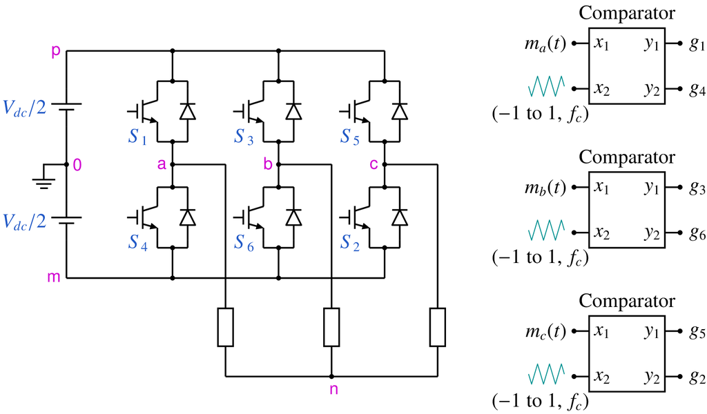

```python
from IPython.display import Image
Image(filename =r'VSI_3ph_5_fig_1.png', width=600)
```

```python
# run this cell to view the circuit file.
%pycat VSI_3ph_5_orig.in
```

We now replace the strings such as `\$Vdcby2`, `\$L`, with the values of our choice by running the python script given below. It takes an existing circuit file `VSI_3ph_5_orig.in` and produces a new circuit file `VSI_3ph_5.in`, after replacing `\$Vdcby2`, `\$L`, etc. with values of our choice.

```python
import gseim_calc as calc
Vdc = 600.0
s_Vdcby2 = ("%11.4E"%(Vdc/2)).strip()

s_L = "0.01"
s_R = "10"
s_f_carrier = "2e3"
s_m1 = "1.12"
s_dt_min = "0.1e-6"
s_dt_nrml = "5e-6"

f1 = 50.0
s_f1 = ("%11.4E"%(f1)).strip()

T = 1/f1
s_2T = ("%11.4E"%(2.0*T)).strip()

l = [
  ('$Vdcby2', s_Vdcby2),
  ('$L', s_L),
  ('$R', s_R),
  ('$f_carrier', s_f_carrier),
  ('$f1', s_f1),
  ('$m1', s_m1),
  ('$2T', s_2T),
  ('$dt_min', s_dt_min),
  ('$dt_nrml', s_dt_nrml)
]
calc.replace_strings_1("VSI_3ph_5_orig.in", "VSI_3ph_5.in", l)
print('VSI_3ph_5.in is ready for execution')
```

```
VSI_3ph_5.in is ready for execution
```

**Execute the following cell to run GSEIM on VSI_3ph_5.in.**

```python
import os
import dos_unix
# uncomment for windows:
#dos_unix.d2u("VSI_3ph_5.in")
os.system('run_gseim VSI_3ph_5.in')
```

```
Circuit: filename = VSI_3ph_5.in
main: calling solve_trns
Transient simulation starts...
i=0
i=1000
i=2000
i=3000
i=4000
i=5000
i=6000
i=7000
i=8000
GSEIM: Program completed.
```

```
0
```

The circuit file (`VSI_3ph_5.in`) is created in the same directory as that used for launching Jupyter notebook. The last step (i.e., running `GSEIM` on `VSI_3ph_5.in`) creates data files called `VSI_3ph_5_1.dat`, etc. in the same directory. We can now use the python code below to compute/plot the various quantities of interest.

```
filename: VSI_3ph_5_1.dat
filename: VSI_3ph_5_2.dat
filename: VSI_3ph_5_3.dat
average power delivered to load:  1.5511E+04
average DC supply current:  2.5807E+01
```

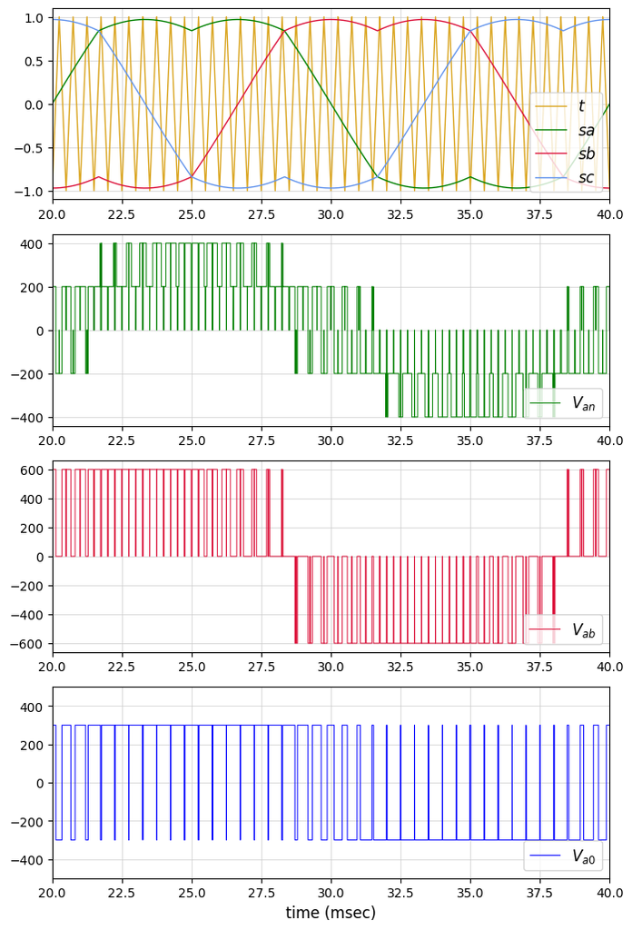

```python
import numpy as np
import matplotlib.pyplot as plt
import gseim_calc as calc
from setsize import set_size

slv = calc.slv("VSI_3ph_5.in")

i_slv = 0
i_out = 0
filename = slv.l_filename_all[i_slv][i_out]
print('filename:', filename)
u1 = np.loadtxt(filename)
t1 = u1[:, 0]

sa = slv.get_array_double(i_slv,i_out,"sa",u1)
sb = slv.get_array_double(i_slv,i_out,"sb",u1)
sc = slv.get_array_double(i_slv,i_out,"sc",u1)
ta = slv.get_array_double(i_slv,i_out,"t" ,u1)
g1 = slv.get_array_double(i_slv,i_out,"g1",u1)
g2 = slv.get_array_double(i_slv,i_out,"g2",u1)
g3 = slv.get_array_double(i_slv,i_out,"g3",u1)
g4 = slv.get_array_double(i_slv,i_out,"g4",u1)
g5 = slv.get_array_double(i_slv,i_out,"g5",u1)
g6 = slv.get_array_double(i_slv,i_out,"g6",u1)

# since we have stored two cycles, we need to divide the last time point
# by 2 to get the period:

T = t1[-1]/2

i_out = 1
filename = slv.l_filename_all[i_slv][i_out]
print('filename:', filename)
u2 = np.loadtxt(filename)
t2 = u2[:, 0]

v_ab = slv.get_array_double(i_slv,i_out,"v_ab",u2)
v_bc = slv.get_array_double(i_slv,i_out,"v_bc",u2)
v_ca = slv.get_array_double(i_slv,i_out,"v_ca",u2)
v_an = slv.get_array_double(i_slv,i_out,"v_an",u2)
v_bn = slv.get_array_double(i_slv,i_out,"v_bn",u2)
v_cn = slv.get_array_double(i_slv,i_out,"v_cn",u2)
v_a0 = slv.get_array_double(i_slv,i_out,"v_a0",u2)
v_b0 = slv.get_array_double(i_slv,i_out,"v_b0",u2)
v_c0 = slv.get_array_double(i_slv,i_out,"v_c0",u2)

i_out = 2
filename = slv.l_filename_all[i_slv][i_out]
print('filename:', filename)
u3 = np.loadtxt(filename)
t3 = u3[:, 0]

IRa  = slv.get_array_double(i_slv,i_out,"IRa",u3)
IRb  = slv.get_array_double(i_slv,i_out,"IRb",u3)
IRc  = slv.get_array_double(i_slv,i_out,"IRc",u3)
IS1  = slv.get_array_double(i_slv,i_out,"IS1",u3)
P_Ra = slv.get_array_double(i_slv,i_out,"P_Ra",u3)
P_Rb = slv.get_array_double(i_slv,i_out,"P_Rb",u3)
P_Rc = slv.get_array_double(i_slv,i_out,"P_Rc",u3)

l_IS1  = calc.avg_rms_3a(t3, IS1 , T, 2.0*T, 1.0e-4*T)
l_P_Ra = calc.avg_rms_3a(t3, P_Ra, T, 2.0*T, 1.0e-4*T)

print('average power delivered to load:', "%11.4E"%(3.0*l_P_Ra[0]))
print('average DC supply current:', "%11.4E"%l_IS1[0])

color1='green'
color2='crimson'
color3='cornflowerblue'
color4='goldenrod'
color5='blue'

fig, ax = plt.subplots(4, sharex=False)
plt.subplots_adjust(wspace=0, hspace=0.0)

set_size(5.5, 8, ax[0])

for i in range(4):
    ax[i].set_xlim(left=T*1e3, right=2.0*T*1e3)
    ax[i].grid(color='#CCCCCC', linestyle='solid', linewidth=0.5)

ax[0].plot(t1*1e3, ta, color=color4, linewidth=1.0, label="$t$")
ax[0].plot(t1*1e3, sa, color=color1, linewidth=1.0, label="$sa$")
ax[0].plot(t1*1e3, sb, color=color2, linewidth=1.0, label="$sb$")
ax[0].plot(t1*1e3, sc, color=color3, linewidth=1.0, label="$sc$")

ax[1].plot(t2*1e3, v_an, color=color1, linewidth=0.7, label="$V_{an}$")

ax[2].plot(t2*1e3, v_ab, color=color2, linewidth=0.7, label="$V_{ab}$")

ax[3].plot(t2*1e3, v_a0, color=color5, linewidth=0.7, label="$V_{a0}$")

ax[3].set_ylim(bottom=-500, top=500)
ax[3].set_xlabel('time (msec)', fontsize=12)

for i in range(4):
    ax[i].legend(loc = 'lower right',frameon = True, fontsize = 10, title = None,
      markerfirst = True, markerscale = 1.0, labelspacing = 0.5, columnspacing = 2.0,
      prop = {'size' : 12},)

plt.tight_layout()
plt.show()
```

```
filename: VSI_3ph_5_1.dat
filename: VSI_3ph_5_2.dat
filename: VSI_3ph_5_3.dat
```

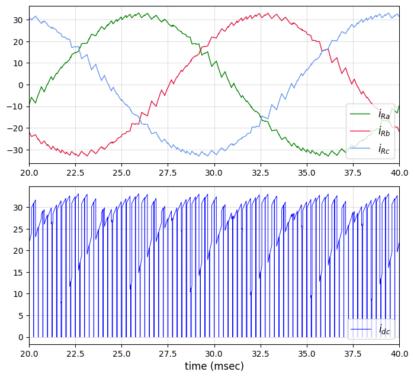

```python
import numpy as np
import matplotlib.pyplot as plt
import gseim_calc as calc
from setsize import set_size

slv = calc.slv("VSI_3ph_5.in")

i_slv = 0
i_out = 0
filename = slv.l_filename_all[i_slv][i_out]
print('filename:', filename)
u1 = np.loadtxt(filename)
t1 = u1[:, 0]

sa = slv.get_array_double(i_slv,i_out,"sa",u1)
sb = slv.get_array_double(i_slv,i_out,"sb",u1)
sc = slv.get_array_double(i_slv,i_out,"sc",u1)
ta = slv.get_array_double(i_slv,i_out,"t" ,u1)
g1 = slv.get_array_double(i_slv,i_out,"g1",u1)
g2 = slv.get_array_double(i_slv,i_out,"g2",u1)
g3 = slv.get_array_double(i_slv,i_out,"g3",u1)
g4 = slv.get_array_double(i_slv,i_out,"g4",u1)
g5 = slv.get_array_double(i_slv,i_out,"g5",u1)
g6 = slv.get_array_double(i_slv,i_out,"g6",u1)

# since we have stored two cycles, we need to divide the last time point
# by 2 to get the period:

T = t1[-1]/2

i_out = 1
filename = slv.l_filename_all[i_slv][i_out]
print('filename:', filename)
u2 = np.loadtxt(filename)
t2 = u2[:, 0]

v_ab = slv.get_array_double(i_slv,i_out,"v_ab",u2)
v_bc = slv.get_array_double(i_slv,i_out,"v_bc",u2)
v_ca = slv.get_array_double(i_slv,i_out,"v_ca",u2)
v_an = slv.get_array_double(i_slv,i_out,"v_an",u2)
v_bn = slv.get_array_double(i_slv,i_out,"v_bn",u2)
v_cn = slv.get_array_double(i_slv,i_out,"v_cn",u2)
v_a0 = slv.get_array_double(i_slv,i_out,"v_a0",u2)
v_b0 = slv.get_array_double(i_slv,i_out,"v_b0",u2)
v_c0 = slv.get_array_double(i_slv,i_out,"v_c0",u2)

i_out = 2
filename = slv.l_filename_all[i_slv][i_out]
print('filename:', filename)
u3 = np.loadtxt(filename)
t3 = u3[:, 0]

IRa  = slv.get_array_double(i_slv,i_out,"IRa",u3)
IRb  = slv.get_array_double(i_slv,i_out,"IRb",u3)
IRc  = slv.get_array_double(i_slv,i_out,"IRc",u3)
IS1  = slv.get_array_double(i_slv,i_out,"IS1",u3)
P_Ra = slv.get_array_double(i_slv,i_out,"P_Ra",u3)
P_Rb = slv.get_array_double(i_slv,i_out,"P_Rb",u3)
P_Rc = slv.get_array_double(i_slv,i_out,"P_Rc",u3)

color1='green'
color2='crimson'
color3='cornflowerblue'
color4='goldenrod'
color5='blue'

fig, ax = plt.subplots(2, sharex=False)
plt.subplots_adjust(wspace=0, hspace=0.0)

set_size(5.5, 5, ax[0])

for i in range(2):
    ax[i].set_xlim(left=T*1e3, right=2.0*T*1e3)
    ax[i].grid(color='#CCCCCC', linestyle='solid', linewidth=0.5)

ax[0].plot(t3*1e3, IRa, color=color1, linewidth=1.0, label="$i_{Ra}$")
ax[0].plot(t3*1e3, IRb, color=color2, linewidth=1.0, label="$i_{Rb}$")
ax[0].plot(t3*1e3, IRc, color=color3, linewidth=1.0, label="$i_{Rc}$")

ax[1].plot(t3*1e3, IS1, color=color5, linewidth=0.7, label="$i_{dc}$")

ax[1].set_xlabel('time (msec)', fontsize=12)

for i in range(2):
    ax[i].legend(loc = 'lower right',frameon = True, fontsize = 10, title = None,
      markerfirst = True, markerscale = 1.0, labelspacing = 0.5, columnspacing = 2.0,
      prop = {'size' : 12},)

plt.tight_layout()
plt.show()
```

```
filename: VSI_3ph_5_1.dat
filename: VSI_3ph_5_2.dat
filename: VSI_3ph_5_3.dat
I_Ra fundamental: RMS value:   2.2726E+01
V_an fundamental: RMS value:   2.3787E+02
```

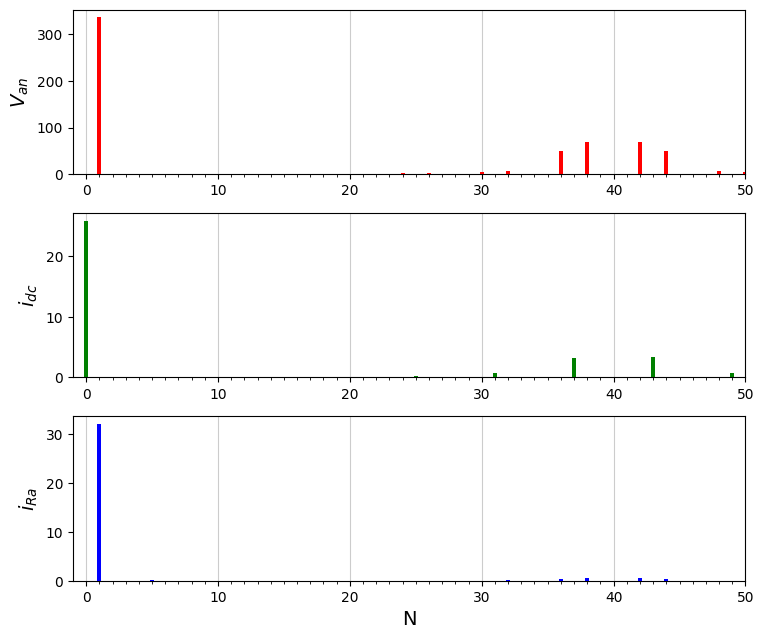

```python
import numpy as np
import matplotlib.pyplot as plt
import gseim_calc as calc
from setsize import set_size

slv = calc.slv("VSI_3ph_5.in")

i_slv = 0
i_out = 0
filename = slv.l_filename_all[i_slv][i_out]
print('filename:', filename)
u1 = np.loadtxt(filename)
t1 = u1[:, 0]

sa = slv.get_array_double(i_slv,i_out,"sa",u1)
sb = slv.get_array_double(i_slv,i_out,"sb",u1)
sc = slv.get_array_double(i_slv,i_out,"sc",u1)
ta = slv.get_array_double(i_slv,i_out,"t" ,u1)
g1 = slv.get_array_double(i_slv,i_out,"g1",u1)
g2 = slv.get_array_double(i_slv,i_out,"g2",u1)
g3 = slv.get_array_double(i_slv,i_out,"g3",u1)
g4 = slv.get_array_double(i_slv,i_out,"g4",u1)
g5 = slv.get_array_double(i_slv,i_out,"g5",u1)
g6 = slv.get_array_double(i_slv,i_out,"g6",u1)

# since we have stored two cycles, we need to divide the last time point
# by 2 to get the period:

T = t1[-1]/2

i_out = 1
filename = slv.l_filename_all[i_slv][i_out]
print('filename:', filename)
u2 = np.loadtxt(filename)
t2 = u2[:, 0]

v_ab = slv.get_array_double(i_slv,i_out,"v_ab",u2)
v_bc = slv.get_array_double(i_slv,i_out,"v_bc",u2)
v_ca = slv.get_array_double(i_slv,i_out,"v_ca",u2)
v_an = slv.get_array_double(i_slv,i_out,"v_an",u2)
v_bn = slv.get_array_double(i_slv,i_out,"v_bn",u2)
v_cn = slv.get_array_double(i_slv,i_out,"v_cn",u2)
v_a0 = slv.get_array_double(i_slv,i_out,"v_a0",u2)
v_b0 = slv.get_array_double(i_slv,i_out,"v_b0",u2)
v_c0 = slv.get_array_double(i_slv,i_out,"v_c0",u2)

i_out = 2
filename = slv.l_filename_all[i_slv][i_out]
print('filename:', filename)
u3 = np.loadtxt(filename)
t3 = u3[:, 0]

IRa  = slv.get_array_double(i_slv,i_out,"IRa",u3)
IRb  = slv.get_array_double(i_slv,i_out,"IRb",u3)
IRc  = slv.get_array_double(i_slv,i_out,"IRc",u3)
IS1  = slv.get_array_double(i_slv,i_out,"IS1",u3)
P_Ra = slv.get_array_double(i_slv,i_out,"P_Ra",u3)
P_Rb = slv.get_array_double(i_slv,i_out,"P_Rb",u3)
P_Rc = slv.get_array_double(i_slv,i_out,"P_Rc",u3)

# compute Fourier coeffs:

t_start = T
t_end = 2.0*T

n_fourier = 50

coeff_v_an, thd_v_an = calc.fourier_coeff_1C(t2, v_an,
    t_start, t_end, 1.0e-8, n_fourier)

coeff_v_a0, thd_v_a0 = calc.fourier_coeff_1C(t2, v_a0,
    t_start, t_end, 1.0e-8, n_fourier)

coeff_IS1, thd_IS1 = calc.fourier_coeff_1C(t3, IS1,
    t_start, t_end, 1.0e-8, n_fourier)

coeff_IRa, thd_IRa = calc.fourier_coeff_1C(t3, IRa,
    t_start, t_end, 1.0e-8, n_fourier)

#print("THD (v_an): ", "%5.2f"%(thd_v_an*100.0), "%")
#print("THD (IRa): " , "%5.2f"%(thd_IRa*100.0) , "%")

print("I_Ra fundamental: RMS value: ", "%11.4E"%(coeff_IRa[1]/np.sqrt(2.0)))
print("V_an fundamental: RMS value: ", "%11.4E"%(coeff_v_an[1]/np.sqrt(2.0)))

x = np.linspace(0, n_fourier, n_fourier+1)

y_v_an  = np.array(coeff_v_an)
y_IS1   = np.array(coeff_IS1 )
y_IRa   = np.array(coeff_IRa )

fig, ax = plt.subplots(3, sharex=False)
plt.subplots_adjust(wspace=0, hspace=0.0)
grid_color='#CCCCCC'

set_size(6, 5, ax[0])

delta = 10.0
x_major_ticks = np.arange(0.0, (float(n_fourier+1)), delta)
x_minor_ticks = np.arange(0.0, (float(n_fourier+1)), 1.0)

for i in range(3):
    ax[i].set_xlim(left=-1.0, right=float(n_fourier))
    ax[i].set_xticks(x_major_ticks)
    ax[i].set_xticks(x_minor_ticks, minor=True)
    ax[i].grid(visible=True, which='major', axis='x', color=grid_color, linestyle='-', zorder=0)

ax[0].set_ylabel('$V_{an}$',fontsize=14)
ax[1].set_ylabel('$i_{dc}$',fontsize=14)
ax[2].set_ylabel('$i_{Ra}$',fontsize=14)

ax[2].set_xlabel('N', fontsize=14)

bars1 = ax[0].bar(x, y_v_an, width=0.3, color='red',   label="$V_{an}$", zorder=3)
bars2 = ax[1].bar(x, y_IS1 , width=0.3, color='green', label="$i_{dc}$", zorder=3)
bars3 = ax[2].bar(x, y_IRa , width=0.3, color='blue',  label="$i_{Ra}$", zorder=3)

plt.tight_layout()
plt.show()
```

This notebook was contributed by **Prof. Nakul Narayanan K**, Govt. Engineering College, Thrissur. He may be contacted at nakul@gectcr.ac.in.